# CSSCR R Workshop

Dadmehr Didgar

2024-1-22

# Introduction to R using R Studio

R is a versatile programming language widely used for statistical analysis and data visualization. Its comprehensive libraries enable effective data manipulation, making it essential for researchers and data scientists. This workshop provides a foundational understanding of R’s syntax and functions, focusing on data handling and graphical representation.

## Simple Calculation

```r
3+4
```

```
## [1] 7
```

```r
2/3
```

```
## [1] 0.6666667
```

```r
5*2
```

```
## [1] 10
```

## `x = 1` vs. `x <- 1`

In R, `x = 1` and `x <- 1` both assign the value `1` to `x`. The traditional `<-` operator is preferred for variable assignments due to its clarity and readability, while `=` is commonly used for specifying function arguments. Though functionally similar in most cases, `<-` is the conventional choice in R scripting for assignment operations.

## Data Type & Assign Values

```r
2.1
```

```
## [1] 2.1
```

```r
F
```

```
## [1] FALSE
```

```r
"Happy"
```

```
## [1] "Happy"
```

```r
"2"
```

```
## [1] "2"
```

```r
a <- 3
## assign the character 2.1 to object called b
b <- "2.1"
## assign the character hello to object called bb
c <- "happy"
## assign the value of object a to object called c
d <- a
```

## Built-in Mathematical Functions

R provides a variety of built-in mathematical functions. Here are a few examples:

- **Square Root**: The `sqrt()` function computes the square root of a number. For example, `sqrt(16)` will give 4.
- **Exponential**: The `exp()` function calculates the exponential of a number. For instance, `exp(1)` computes e^1, which is approximately 2.7182818.
- **Logarithm**: The `log()` function computes logarithms. `log(10)` gives the natural logarithm of 10, equal to 2.3025851.
- **Trigonometry**: Functions like `sin()`, `cos()`, and `tan()` are used for trigonometric calculations.

These functions exemplify the simplicity and power of R for mathematical computations.

## Types of Objects

```r
# vector
numbers <- c(1,4,2)

colors <- c("lightgreen", "pink", "blue")

# data frame
demo_data <-    data.frame(
  gender = c("Male", "Male","Female"),
  height = c(152, 171.5, 165),
  weight = c(81,93, 78),
  Age    = c(42,38,26)
  )

# list
mylist <- list(2.1, c(1,3,7), c("abc", "def"), demo_data)
```

# If Clause in R

```r
x <- 5

if (x > 0) {
  print("x is positive")
} else {
  print("x is not positive")
}
```

```
## [1] "x is positive"
```

# For Loop in R

```r
for (i in 1:5) {
  print(i)
  #print(paste("Value of i is", i))
}
```

```
## [1] 1
## [1] 2
## [1] 3
## [1] 4
## [1] 5
```

# Census Data

CSSCR_data is a small random sample (0.005%) of the census data for 2022

```r
# sampled_data <- data[sample(nrow(data), nrow(data) * 0.00005), ]

CSSCR_data <- data.frame(AGE = c(36, 66, 48, 84, 76, 61, 69, 33, 95, 61, 83, 69, 29, 73, 28, 80, 49, 48, 30, 54, 65, 71, 23, 67, 74, 81, 58, 76, 49, 29, 21, 33, 62, 25, 22, 24, 18, 40, 27, 23, 81, 62, 61, 28, 30, 40, 84, 21, 50, 27, 75, 37, 50, 71, 23, 74, 57, 35, 64, 62, 42, 50, 16, 65, 70, 43, 33, 37, 61, 18, 64, 52, 72, 35, 33, 79, 82, 42, 50, 60, 19, 74, 69, 82, 47, 37, 62, 58, 39, 20, 74, 68, 62, 17, 74, 78, 54, 28, 32, 82, 30, 42, 31, 53, 37, 53, 79, 51, 71, 76, 63, 54, 42, 25, 77, 41, 55, 75, 45, 16, 61, 56, 65, 16))


CSSCR_data$INCTOT <- c(100000, 11600, 105000, 79400, 2300, 73000, 138000, 15000, 24000, 96900, 9300, 35600, 21010, 7400, 500, 8430, 960, 39000, 50000, 100000, 31000, 18000, 27000, 9600, 466800, 28300, 49900, 33000, 8000, 80000, 35000, 30000, 2500, 24400, 4700, 30000,
 14000, 45000, 46000, 65000, 39000, 36600, 75000, 56000, 25000, 170000, 16800, 18300, 400, 40000, 1900, 75000, 12000, 125600, 30000, 15100, 226000, 60000, 70000, 60000, 28000, 12130, 570, 23300, 13800, 8000, 54000, 15750, 41000, 1600, 200000, 71000, 30000, 70000, 40000, 45200, 10500, 64000, 90000, 44500, 12800, 64100, 30100, 47000, 45000, 51000, 88000, 180000, 90000, 3000, 10400, 9100, 579000, 4000, 107000, 49400, 9600, 114000, 39000, 22700, 20000, 14200, 40000, 25000, 20000, 50000, 25100, 14000, 22000, 45300, 1900, 30000, 56400, 40000, 9700, 50000, 20000, 9000, 80000, 300, 42400, 40000, 24800, 1200)
```

## Data Analysis Essentials

The R code provided performs fundamental data analysis operations on the `CSSCR_data` dataset.

```r
dim(CSSCR_data)
```

```
## [1] 124   2
```

```r
mean(CSSCR_data$INCTOT)
```

```
## [1] 50146.37
```

```r
median(CSSCR_data$INCTOT)
```

```
## [1] 30550
```

```r
mean(CSSCR_data$AGE)
```

```
## [1] 51.5
```

```r
median(CSSCR_data$AGE)
```

```
## [1] 53
```

## Count

```r
#install.packages("dplyr")
library(dplyr)
count(CSSCR_data,AGE > 30)
```

```
##   AGE > 30  n
## 1    FALSE 27
## 2     TRUE 97
```

```r
help("count")
?count
```

## Simple Plot

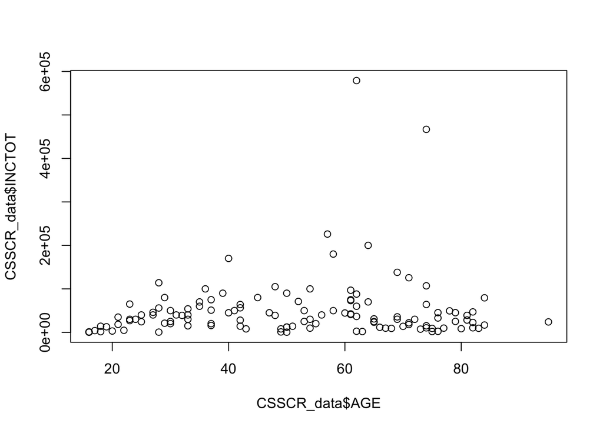

```r
plot(CSSCR_data$AGE, CSSCR_data$INCTOT)
```

## Less Simple Plot

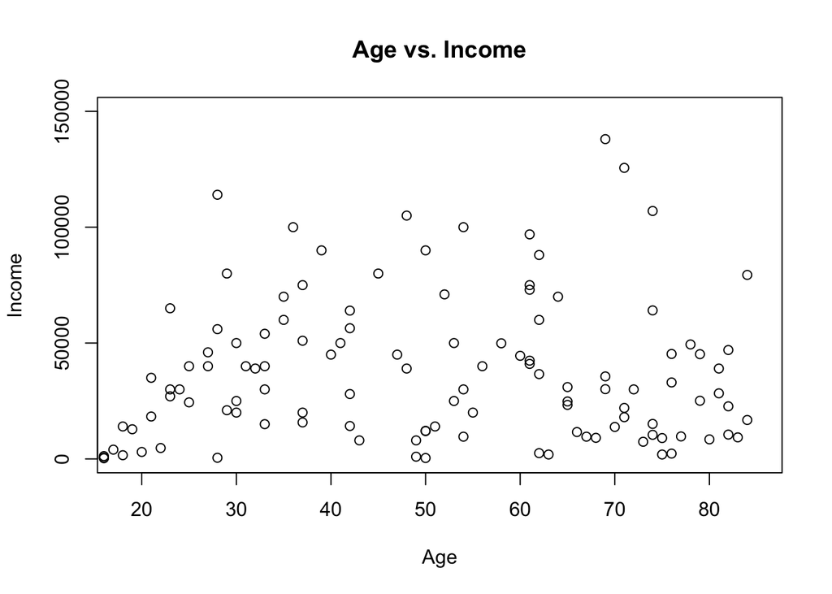

```r
plot(CSSCR_data$AGE, CSSCR_data$INCTOT,
     main = "Age vs. Income",
     xlab = "Age",
     ylab = "Income",
     ylim = c(0,150000),
     xlim = c(18,85))
```

```r
?plot
```

```
## Help on topic 'plot' was found in the following packages:
##
##   Package               Library
##   base                  /Library/Frameworks/R.framework/Resources/library
##   graphics              /Library/Frameworks/R.framework/Versions/4.3-arm64/Resources/library
##
##
## Using the first match ...
```

## Fancy Plot

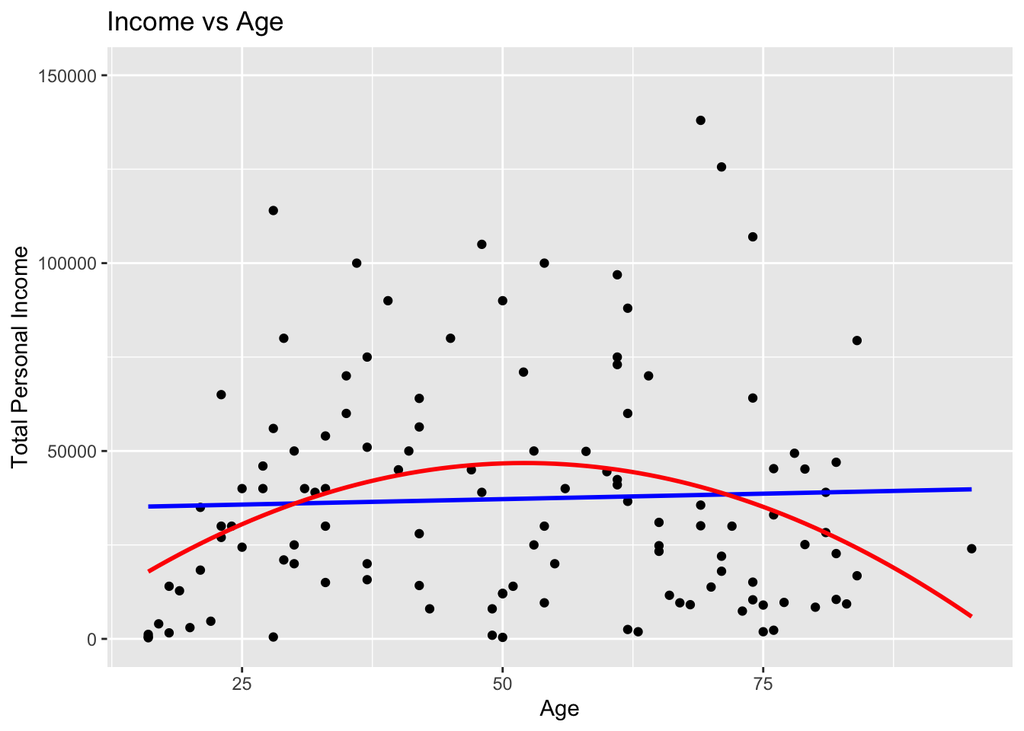

```r
# Install and load the ggplot2 package
#install.packages("ggplot2")

library(ggplot2)

# Plotting
ggplot(CSSCR_data, aes(x = AGE, y = INCTOT)) +
  geom_point() +  # Scatter plot
  geom_smooth(method = "lm", se = FALSE, color = "blue") +  # Linear fit
  geom_smooth(method = "lm", formula = y ~ poly(x, 2), se = FALSE, color = "red") +  # Quadratic fit
  ylim(0, 150000) +
  labs(title = "Income vs Age", x = "Age", y = "Total Personal Income")
```